# RUGS

Gaurav Chaturvedi

12/31/2015

# Introduction

One of the main advantages to using the `data.table` package is the speed at which it is able to perform all kinds of data wrangling operations.

In this Rmarkdown document, we will present benchmarking of common operations, comparing the speed of `data.table` in performing those operations to that of `dplyr`. We will also demonstrate the syntactical comparisons between the 2 packages.

## Packages used in this document

The `suppressMessages` method was used to suppress the package loading messages.

```r
# The 2 main data manipulation packages to test:
suppressMessages(library(dplyr))
suppressMessages(library(data.table))

# For date parsing and manipulation:
suppressMessages(library(lubridate))

# For benchmarking:
suppressMessages(library(microbenchmark))
```

## About the Dataset

The dataset used in performing these benchmarking tests is obtained from a property rental website, recording interactions between interested users with rental property listings. There are 1,882,945 observations and 8 variables, a summary of which has been provided below:

```
##          prop_id                user_id            contact_date
##  ff80814e020d:    872   ff8081f4049b:   1861   2015-10-10:  11768
##  ff8081ed255f:    720   ff8081300461:   1516   2015-10-17:  11709
##  ff80814637bc:    630   ff8081eb1f1e:    279   2015-09-12:  11396
##  ff80810606e8:    619   ff8081841f97:    230   2015-09-13:  11363
##  ff80811b23eb:    605   ff8081aa2956:    192   2015-11-21:  11022
##  ff8081b51f92:    573   ff80818f4850:    187   2015-11-28:  10878
##  (Other)     :1878926   (Other)     :1878680   (Other)   :1814809
##  city             type        property_size           rent
##  A:668346   BHK1    :722657   Min.   :       0   Min.   :    -1
##  B:255822   BHK2    :780701   1st Qu.:     500   1st Qu.:  7000
##  C:654036   BHK3    :155862   Median :     695   Median : 11000
##  D:304741   BHK4    :  6896   Mean   :     818   Mean   : 13482
##             BHK4PLUS:  1922   3rd Qu.:    1000   3rd Qu.: 16000
##             RK1     :214907   Max.   :13009089   Max.   :650000
##
##       inactive_reason
##  LETOUT_BYME  :304684
##  LETOUT_OTHERS:961674
##  NA's         :616587
##
##
##
##
```

# Speed Test

## Reading data

We begin our benchmarking with data reading as the `data.table` package provides an internal method of reading data into a datatable object. The main purpose for providing such a method is to make the data parsing process as painless and quick as possible, as opposed to `dplyr`, which requires you to use the base read methods:

```r
# Using data.table's fread method
microbenchmark(
    datatable = (
        dt_raw <- fread("rugsdply.csv", showProgress = F)
    ),
    dplyr = (
        dplyr_raw <- tbl_df(read.csv("rugsdply.csv", stringsAsFactors = F))
    ),
    times = 5
)
```

```
## Unit: seconds
##       expr       min        lq     mean    median        uq       max
##  datatable  2.378588  2.441333  2.47179  2.498937  2.505444  2.534649
##      dplyr 12.215137 12.275740 12.38686 12.331944 12.488671 12.622804
##  neval cld
##      5  a
##      5   b
```

As you can see, reading the data using data table’s fread function is much faster. Lets do another speed test with a dedupe data manipulation. We use the simpler system.time function this time.

## Eliminate duplicates (user_id, Property_id combinations); keep the first instance by request_date

```r
# DPLYR
system.time(cdedup_dplyr <- dplyr_raw %>% arrange(contact_date) %>% group_by (prop_id, user_id) %>% filter(1:n() == 1))
```

```
##    user  system elapsed
##   58.45    0.17   58.64
```

```r
# DATA TABLE

system.time({setorderv(dt_raw, "contact_date")
setkeyv(dt_raw, c("user_id", "prop_id"))
cdedup_dt <- unique(dt_raw)})
```

```
##    user  system elapsed
##    1.04    0.02    1.08
```

Don’t bother about the syntax right now.

In this cases speed difference is around 40-100x. Why is speed so critical? Think of adhoc analysis, dashboard, customer browsing properties on portal.

Experts say that the speed difference between the 2 packages is in evidence with data sets >100k rows.

Having demonstrated the speed difference, we focus on the syntax of the 2 packages in the next part.We will refer to relative speeds where it is relevant.

# DPLYR vs DATA TABLE syntax

## Add/Remove/Modify Columns

In this example, assuming that `property_size` is recorded in square feet, a particularly useful measure might be the rental cost per square feet, which would allow interested parties identify the properties that provide the most return per $ paid in rent.

Additionally, since all file parsing methods would inevitably parse date columns as character strings, it would be useful to convert date columns into POSIXct type. Lubridate is used to quickly convert dates in both cases, and add a `contact_mthyr` column for easy aggregation later. Because the last operation is contingent on the `contact_date` column being converted into a POSIXct type, we will have to chain that operation:

```r
         dt_mutate <- copy(dt_raw)
         dt_mutate[, `:=`(
             rent_persqft = rent / property_size,
             contact_date = ymd(contact_date)
         )
         ][, contact_mthyr := format(contact_date, "%b-%Y")] # Chaining

#          dplyr_mutate <- cdedup_dplyr
#          dplyr_mutate$rent_persqft <- dplyr_mutate$rent / dplyr_mutate$property_size
#          dplyr_mutate$contact_date <- as.Date(dplyr_mutate$contact_date, "%Y-%m-%d")
#          dplyr_mutate$contact_mthyr <- format(dplyr_mutate$contact_date, "%b-%Y")

           dplyr_mutate <- dplyr_raw %>%
             mutate(contact_date = ymd(contact_date),
                    rent_persqft = rent / property_size) %>%
             mutate(contact_mthyr = format(contact_date, "%b-%Y"))
```

Chaining refers to the practice of using consecutive [] operations one after the other.

‘:=’ is creating a new column by reference (in the same dataset dt_mutate).

## Group Summarise - get the count and median(rent) of all contacts by city

```r
# DPLYR
gs2_df <- cdedup_dplyr %>% group_by(city) %>% summarise(med_rent = round(median(rent),0), ccts = n())
gs2_df
```

```
## Source: local data frame [4 x 3]
##
##    city med_rent   ccts
##   (chr)    (dbl)  (int)
## 1     A    11000 483981
## 2     B     9500 180406
## 3     C    13000 469955
## 4     D    10000 213458
```

```r
# DATA TABLE
gs2_dt <- cdedup_dt[, list(med_rent= round(median(rent),0), ccts = .N), by=city]
gs2_dt
```

```
##    city med_rent   ccts
## 1:    C    13000 469955
## 2:    A    11000 483981
## 3:    D    10000 213458
## 4:    B     9500 180406
```

If you time the above 2 operations (mutate and summarise), you will notice that the speed difference between the 2 packages in these cases is not substantial. The reason is that the grouping and the operation is very simple. Let us try something more complex.

## Find out mean rental by city for 2 buckets property size <= 500 and property size > 500

```r
# DPLYR
system.time (gs3_df <- cdedup_dplyr %>% mutate(props_bkt = ifelse(property_size <= 500, TRUE, FALSE))%>% group_by (city,props_bkt) %>% summarise(mean_rent = as.integer(mean(rent))))
```

```
##    user  system elapsed
##   26.23    0.00   26.23
```

```r
gs3_df
```

```
## Source: local data frame [8 x 3]
## Groups: city [?]
##
##    city props_bkt mean_rent
##   (chr)     (lgl)     (int)
## 1     A     FALSE     14681
## 2     A      TRUE      7046
## 3     B     FALSE     12113
## 4     B      TRUE      6157
## 5     C     FALSE     20081
## 6     C      TRUE     12031
## 7     D     FALSE     11608
## 8     D      TRUE      6582
```

```r
# DATA TABLE
system.time (gs3_dt <- cdedup_dt[, list(mean_rent = as.integer(mean(rent))), by=list(city,props_bkt = property_size <=500 )])
```

```
##    user  system elapsed
##    0.03    0.00    0.04
```

```r
gs3_dt
```

```
##    city props_bkt mean_rent
## 1:    C     FALSE     20081
## 2:    C      TRUE     12031
## 3:    A     FALSE     14681
## 4:    A      TRUE      7046
## 5:    D     FALSE     11608
## 6:    B     FALSE     12113
## 7:    B      TRUE      6157
## 8:    D      TRUE      6582
```

```r
gs3_dt <- cdedup_dt[, list(mean_rent = as.integer(mean(rent))), by=list(city,props_bkt = property_size <=500 )][order(mean_rent)]  # Chaining
gs3_dt
```

```
##    city props_bkt mean_rent
## 1:    B      TRUE      6157
## 2:    D      TRUE      6582
## 3:    A      TRUE      7046
## 4:    D     FALSE     11608
## 5:    C      TRUE     12031
## 6:    B     FALSE     12113
## 7:    A     FALSE     14681
## 8:    C     FALSE     20081
```

The speed difference in this case is noticeable. Data table scales better as the number of groups increase.

Let us try some data aggregation now.

## Data Aggregation

Because data can be fairly granular when extracted from the server, it may be necessary aggregate it to a higher level. In this example, we may like to analyse the interactions regardless of property, user or inactive reasons by month in order to discover the average rent asked for per month:

```r
microbenchmark(
    datatable = (
        dt_agg <- dt_mutate[, lapply(.SD, mean), by = .(contact_mthyr, city, type),
                         .SDcols = c("property_size", "rent", "rent_persqft")]
    ),
    dplyr = (
        dplyr_agg <- dplyr_mutate %>%
            group_by(contact_mthyr, city, type) %>%
            summarise(property_size = mean(property_size),
                      rent = mean(rent),
                      rent_persqft = mean(rent_persqft))
    ),
    times = 5
)
```

```
## Unit: milliseconds
##       expr      min       lq     mean   median       uq      max neval cld
##  datatable 204.4385 205.7825 206.4965 206.5874 207.8185 207.8556     5  a
##      dplyr 335.1689 335.3059 337.3745 335.4030 338.7506 342.2439     5   b
```

Notice the data table syntax using .SD and .SDCols. Data table is again quicker due to the complex grouping.

## Table Reshaping

Sometimes your data may come in in a wide table, rather than a long one (i.e. a common example being dates as column headers). We would commonly use the `reshape2` package to melt and cast the tables, but with recent versions of `data.table`, these methods have been internalised in order to better work with the data structures.

```r
# Benchmarking for casting
microbenchmark(
    datatable = (
        dt_dcast <- dcast(dt_agg, city + type ~ contact_mthyr, value.var = "rent")
    ),
    dplyr = (
        dplyr_dcast <- reshape2::dcast(dplyr_agg, city + type ~ contact_mthyr,
                                       value.var = "rent")
    ),
    times = 5
)
```

```
## Unit: milliseconds
##       expr      min       lq     mean   median       uq        max neval
##  datatable 2.926076 2.959234  3.52637 2.968707 3.495661   5.282174     5
##      dplyr 1.745463 1.779408 25.97059 1.840196 1.940455 122.547443     5
##  cld
##    a
##    a
```

```r
# Benchmarking for melting
microbenchmark(
    datatable = (
        dt_melt <- melt(dt_dcast, id.vars = c("city", "type"),
                        variable.name = c("contact_mthyr"), value.name = "rent",
                        variable.factor = F)
    ),
    dplyr = (
        dplyr_melt <- reshape2::melt(dt_dcast, id.vars = c("city", "type"),
                                      variable.name = c("contact_mthyr"),
                                      value.name = "rent",
                                      variable.factor = F)
    ),
    times = 5
)
```

```
## Unit: microseconds
##       expr     min      lq     mean  median      uq     max neval cld
##  datatable 215.520 216.309 220.0190 217.098 219.466 231.702     5   a
##      dplyr 215.914 217.493 299.5948 236.439 281.437 546.691     5   a
```

```r
# DPLYR
system.time(gs4_df <- cdedup_dplyr %>% group_by(user_id)%>% mutate(cntcts = n()) %>% filter(cntcts >=3) %>% summarise(rent_sd = sd(rent)))
```

```
##    user  system elapsed
##   28.34    0.05   28.39
```

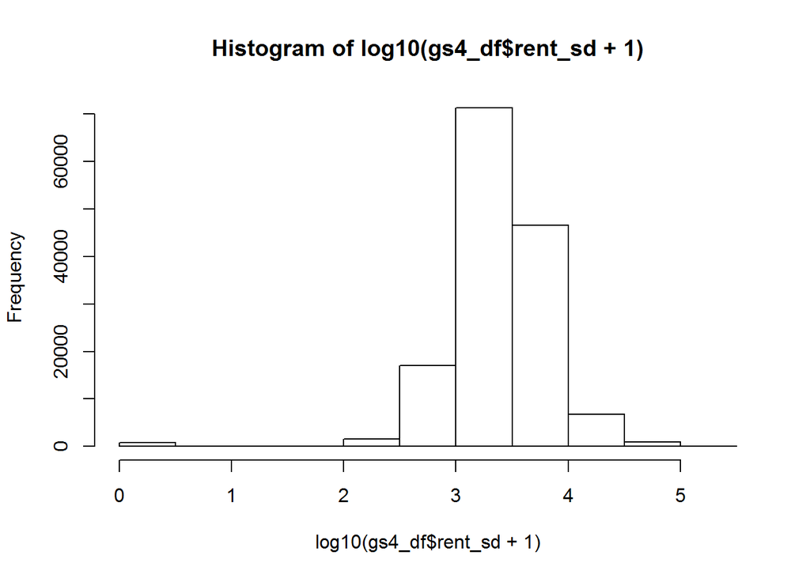

```r
hist(log10(gs4_df$rent_sd+1))
```

```r
# DATA TABLE
system.time ( {
  setkey(cdedup_dt, user_id)
  gs4_dt <- cdedup_dt[, cntcts := .N, by=user_id][cntcts >=3, list(rent_sd=sd(rent)), by=user_id]
  }
  )
```

```
##    user  system elapsed
##    2.89    0.02    2.91
```

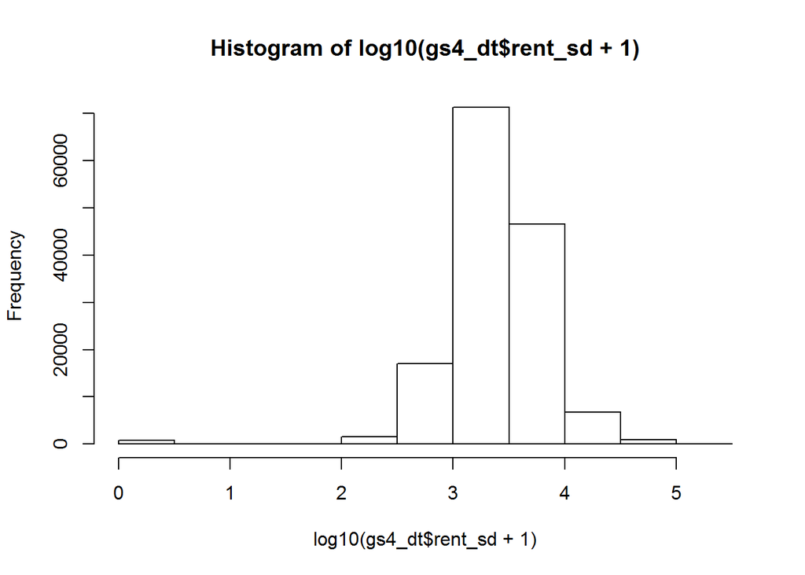

```r
hist(log10(gs4_dt$rent_sd+1))
```

In this case we again use Chaining as we want step1 to just add a new column with number of contacts (for userid) and then filter using that outcome followed by step2 where we group by userid.

‘:=’ is creating a new column by reference (in the same dataset). After this operation notice that even cdedup_dt has a new column called ‘cntcts’.

‘.N’ is count of rows

If you used list instead of .N in step1, that would create a summary table in the first step of the chain. We dont want that.

The outcome shows most users tolerate rental deviation of around $1,000. This will be useful if we wish to recommend properties to users who have some browsing history on the website.